Computer Vision Workspace  
Dr. Saed Imran  
simr.dk@gmail.com

# Detect Color

- Show image, with nearest neighbour interpolation `plt.imshow(image, interpolation='nearest')`
- Blur image `cv2.GaussianBlur(image, (7, 7), 0)`
- Detect Color `cv2.inRange(image_blur_hsv, min_red, max_red)`
- Cleaning, used morphology technique to close (fill voids / blanks space) and then open (remove small specks).  
  `kernel = cv2.getStructuringElement(cv2.MORPH_ELLIPSE, (15, 15))`
  - Filling small gaps `image_red_closed = cv2.morphologyEx(image_red, cv2.MORPH_CLOSE, kernel)`
  - Removing small specs specks `image_red_closed_then_opened = cv2.morphologyEx(image_red_closed, cv2.MORPH_OPEN, kernel)`

Output

Cherry detection

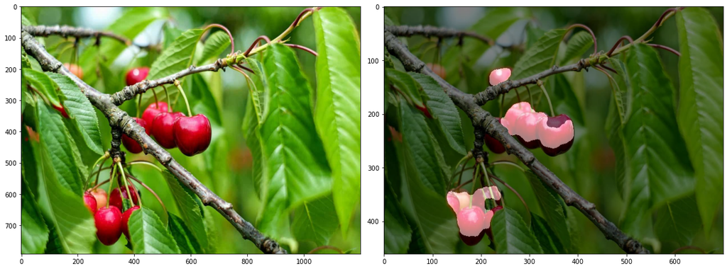

Riped tomatos detection

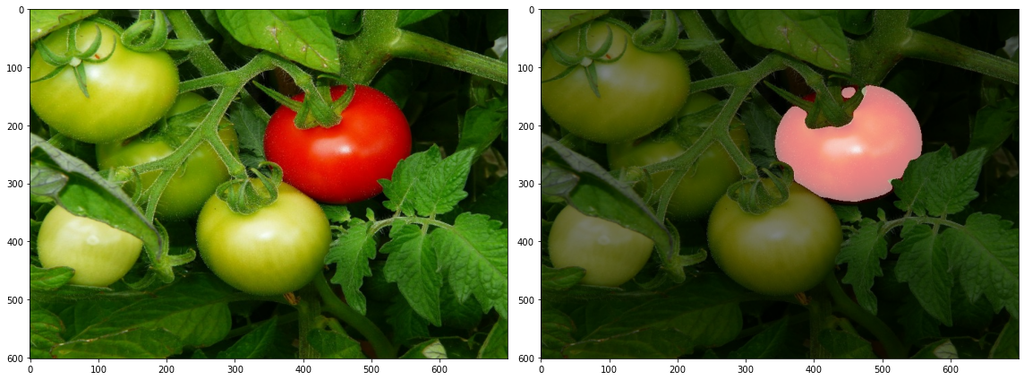

# Extracting text from Image (OCR)

- Python-tesseract is used for optical character recognition (OCR) tool for python. To download binary: https://github.com/UB-Mannheim/tesseract/wiki
- setting threshold `retval, threshold = cv2.threshold(image,127,255,cv2.THRESH_BINARY)`
  - different thrheshold techniques: https://docs.opencv.org/3.4.0/d7/d4d/tutorial_py_thresholding.html
- run tesseract, which gives us string as an output. `text = pytesseract.image_to_string(threshold)`

Output

Extracting text from my LinkedIn profile

[figure not shown]

---

---

---

Extracting text from image

[figure not shown]

# Find most-common colors using k-means clustering in an image

- Image color clusterung using `from sklearn.cluster import KMeans`
- Based on image setting num of clusters: `KMeans(n_clusters=num_clusters)`
- Histogram based on RGB values `cv2.COLOR_BGR2RGB` & HSV valuses`cv2.COLOR_BGR2HSV`

Output

Most common colors

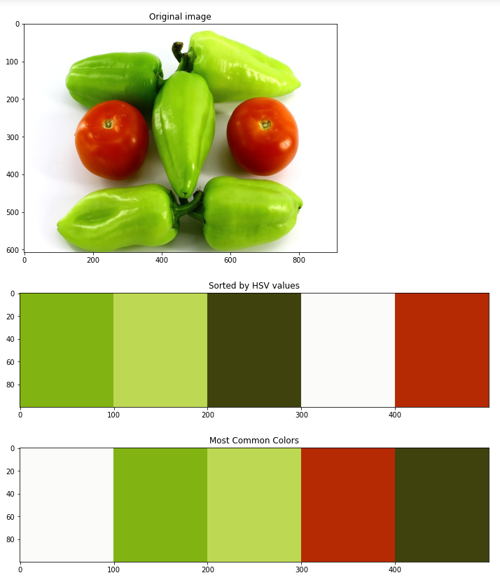

Most common colors detection

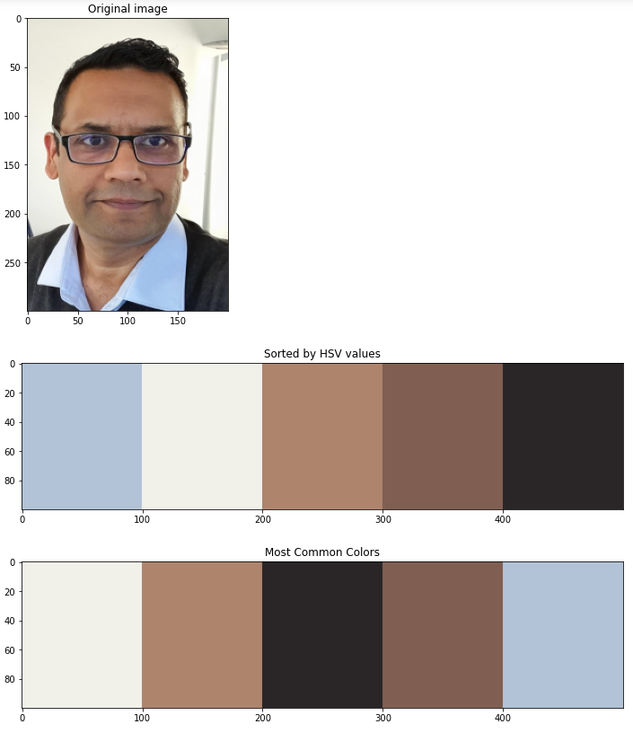

# Detect Contours in Images

- Convert the image to a binary thresholded image `_, binary = cv2.threshold(gray, 225, 255, cv2.THRESH_BINARY_INV)`
- find the contours from the thresholded image `contours, hierarchy = cv2.findContours(binary, cv2.RETR_TREE, cv2.CHAIN_APPROX_SIMPLE)`
- draw all contours `image = cv2.drawContours(image, contours, -1, (0, 255, 0), 2)`

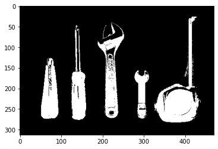

|

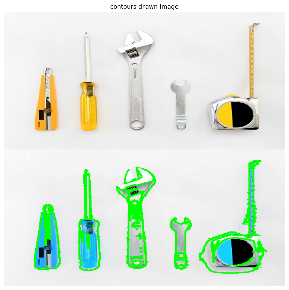